# Preliminary EDA

```r
library('tidyverse')
frmgham <- read_csv('frmgham2.csv')
frmgham_kaggle <- read_csv('framingham.csv')
problems(frmgham)
```

| row | col | expected | actual |
| --- | --- | --- | --- |

```r
problems(frmgham_kaggle)
```

| row | col | expected | actual |
| --- | --- | --- | --- |

## Intial Analysis

```r
pop_tb <- as.data.frame(table(frmgham$AGE, frmgham$SEX))
pop_tb
```

| Var1 | Var2 | Freq |
| --- | --- | --- |
| 32 | 1 | 0 |
| 33 | 1 | 2 |
| 34 | 1 | 5 |
| 35 | 1 | 17 |
| 36 | 1 | 43 |
| 37 | 1 | 45 |
| 38 | 1 | 70 |
| 39 | 1 | 76 |
| 40 | 1 | 88 |
| 41 | 1 | 94 |

[output cut: 90 more lines]

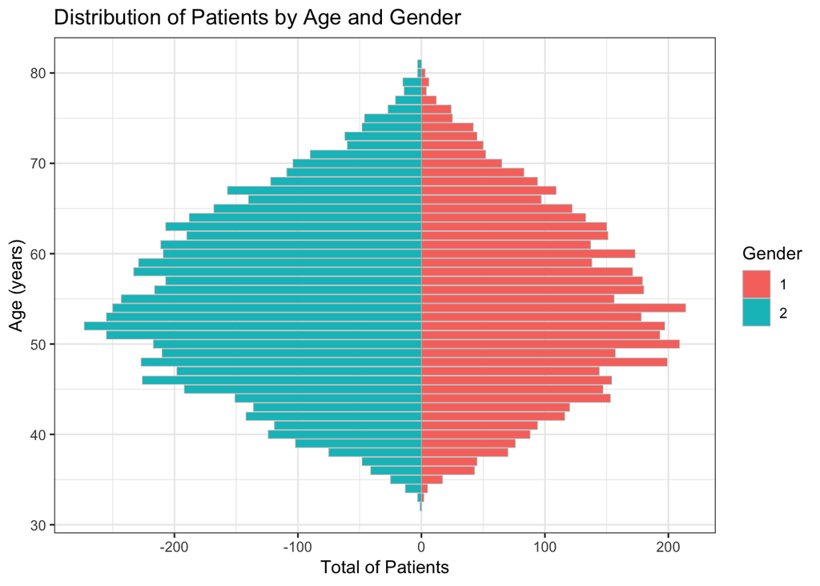

```r
names(pop_tb)[1] <- paste("Age")
names(pop_tb)[2] <- paste("Gender")

pop_tb$Age <- as.numeric(as.character(pop_tb$Age))


# Plot Age Range with respective Frequencies and label with Gender orientation
ggplot(pop_tb, aes(x = Age, y = Freq, fill = Gender)) +
 # Define each gender in barplot distribution
geom_bar(data = subset(pop_tb, Gender == 1), stat = "identity", mapping = aes(y = Freq), color="grey", size=0.2) +
 geom_bar(data = subset(pop_tb, Gender == 2), stat = "identity", position = "identity", mapping = aes(y = -Freq), color="grey", size=0.2) +
 # Define the limits on scales

 # Turn to horizontal barplots
 coord_flip() +
 # Title, Legend
 theme_bw() +
 xlab("Age (years)") +
 ylab("Total of Patients") +
 ggtitle("Distribution of Patients by Age and Gender")
```

Checking the distribution of different traits based on the education

```r
frmgham %>% group_by(educ) %>% filter(!is.na(BMI),!is.na(educ)) %>% summarise(mean_bmi=mean(BMI))
```

| educ | mean_bmi |
| --- | --- |
| 1 | 26.60309 |
| 2 | 25.54164 |
| 3 | 24.96266 |
| 4 | 25.27470 |

```r
frmgham %>% group_by(educ) %>% filter(!is.na(HEARTRTE),!is.na(educ)) %>% summarise(mean_heart_rate=mean(HEARTRTE))
```

| educ | mean_heart_rate |
| --- | --- |
| 1 | 76.95709 |
| 2 | 77.64751 |
| 3 | 76.75756 |
| 4 | 74.23088 |

```r
frmgham %>% group_by(educ) %>% filter(!is.na(GLUCOSE),!is.na(educ)) %>% summarise(mean_glucose=mean(GLUCOSE))
```

| educ | mean_glucose |
| --- | --- |
| 1 | 85.90331 |
| 2 | 83.26885 |
| 3 | 82.95618 |
| 4 | 82.26811 |

## Discussion for initial analysis

we analysed the framigham data set to check how a socieconomic status and access to higher levels of education affected factors such as bmi(body mass index),heart rate and glucose level(we assessed glucose levels because constant high glucose level(hyperglycemia) are correlated with high risk for certain lifestyle diseases.

Blood glucose levels range from 90 to 130 mg/dL before meals, and below 180 mg/dL within 1 to 2 hours after a meal. In general, most people without diabetes have blood sugar levels before meals hover around 70 to 80 mg/dL: 60 is normal; for others, 90.Hypoglycemia, also called low blood glucose or low blood sugar, occurs when the level of glucose in your blood drops below normal. For many people with diabetes, that means a level of 70 milligrams per deciliter (mg/dL) or less. Glucose: the mean glucose levels decreased as education levels increased. Higher education levels were assocaited with lower and slightly healthier glucose levels. Overall, the mean glucose levels for all groups were fell within a healthy range for glucose levels.

## Logistic Models

Some of the early logistic models

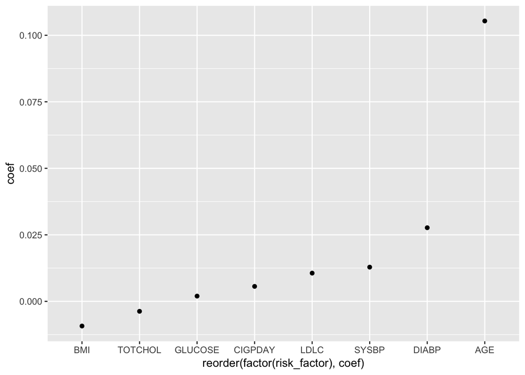

```r
#Predicting presence of Coronary Heart Disease using risk factors
beta <- coef(glm(PREVCHD ~ BMI + TOTCHOL + AGE + SYSBP + GLUCOSE + CIGPDAY + LDLC,data=frmgham,family=binomial()))

#Predicting prevalence of Stroke using risk factors
beta_1 <- coef(glm(PREVSTRK ~ BMI + TOTCHOL + AGE + SYSBP + DIABP + GLUCOSE + CIGPDAY + LDLC,data=frmgham,family=binomial()))

preval_chd <- as.tibble(as.list(beta[-1])) %>% gather(risk_factor,coef)

preval_strk <- as.tibble(as.list(beta_1[-1])) %>% gather(risk_factor,coef)

ggplot(preval_strk,aes(reorder(factor(risk_factor), coef), coef)) + geom_point()
```

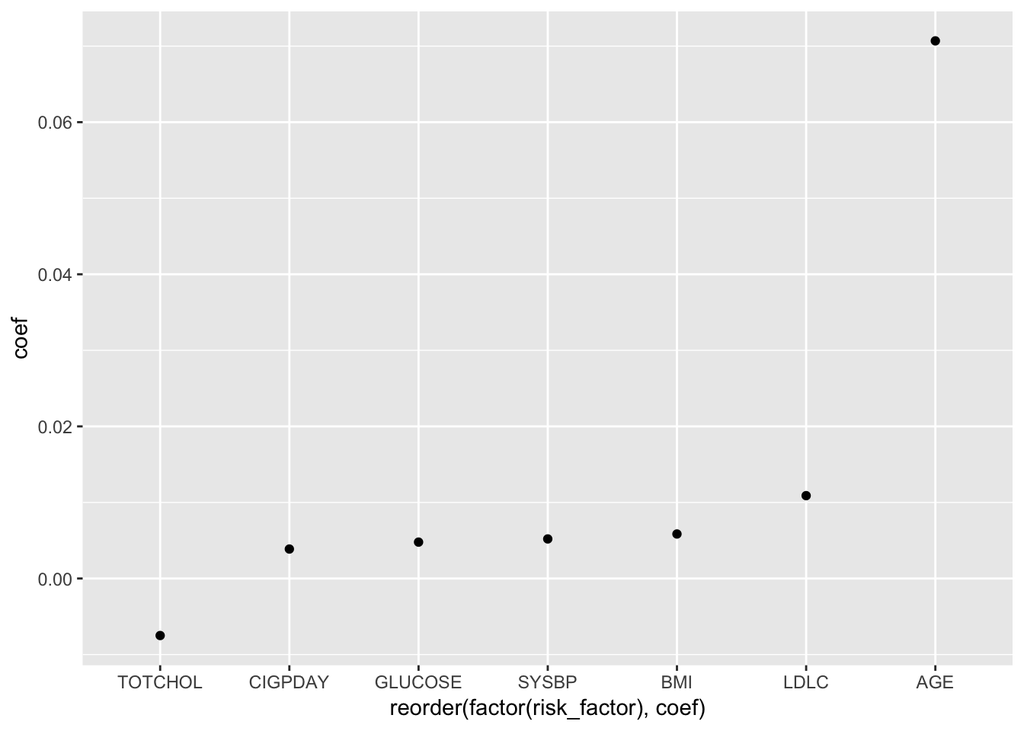

```r
ggplot(preval_chd,aes(reorder(factor(risk_factor), coef), coef)) + geom_point()
```

## Discussion For this part,we used a logistic regression model to predict the presence of Coronary Heart Disease using risk factors such as BMIBody Mass Index(BMI), TOTCHOL(Total Cholestrol levels), AGE(Age), Systolic Blood Pressure(SYSBP), GLUCOSE, the number of cigarettes per day(CIGPDAY) and Blood levels of Low-density lipoprotein (LDL) is one of the body’s lipoproteins and an important carrier of cholesterol.LDL cholesterol (LDL-C) are often assessed when evaluating the risk of future heart disease.

AGE:From our model, age was the highest risk factor for predicting the presence of Coronary Heart Disease. It would be expected that the older one gets, the higher the risk for developing chronic and lifestyle diseases.

Another important distinction was noted between TOTAL CHOL level and LDLC levels. One would expect higher levels of total cholestrol(TOTCHOL) to be a higher predictor but using logistic regression model to asses the framigham dataset, Higher Levels of Low-density lipoprotein (LDL) put one at a higher risk of cornary heart disease more than the former.

```r
frmgham_mod<- frmgham %>%
  mutate(BMI_Class=case_when(BMI<18.5~'Underweight',BMI >= 18.5 & BMI <25 ~ 'Normal',BMI >= 25 & BMI < 30 ~ 'Overweight',BMI>=30 & BMI<35 ~ 'Obese',BMI>=35 ~ 'Super Obese'))

# SUMMARY OF Mean Heart Rates by BMI category
frmgham_mod %>% group_by(BMI_Class) %>% filter(!is.na(HEARTRTE) & !is.na(BMI)) %>% summarise(mean_heart_rate=mean(HEARTRTE))
```

| BMI_Class | mean_heart_rate |
| --- | --- |
| Normal | 76.32903 |
| Obese | 78.37550 |
| Overweight | 76.36468 |
| Super Obese | 81.61635 |
| Underweight | 80.72892 |

```r
# SUMMARY OF Mean Glucose Levels by BMI category
frmgham_mod %>% group_by(BMI_Class) %>% filter(!is.na(GLUCOSE) & !is.na(BMI)) %>% summarise(mean_glu=mean(GLUCOSE))
```

| BMI_Class | mean_glu |
| --- | --- |
| Normal | 82.78684 |
| Obese | 87.48876 |
| Overweight | 84.16623 |
| Super Obese | 91.54167 |
| Underweight | 85.38849 |

## BMI Based Categorisation

BMI is categorized in the following ranges so as to classify which weight category an individual falls into. Underweight: BMI is less than 18.5. Normal weight: BMI is 18.5 to 24.9. Overweight: BMI is 25 to 29.9. Obese: BMI is 30 or more. Super Obese: 35 or more.

Heart Rate: A normal resting heart rate for adults ranges from 60-100 beats per minute. Usually, a lower heart rate at rest connotes a more efficient heart function and better cardiovascular fitness. For example, a well-trained athlete might have a normal resting heart rate closer to 40 beats per minute.

We used BMI classes( Underweight, normal weight, overweight, obese and super obese) to evaluate how the heart rate varies. Individuals who had a normal BMI_Class had the lowest heart rate(76.32903) which implies they were the healthiest. As the BMI Class increased from normal to super obese, we observed that heart rate increased even though overall it fell under a healthy range. Last of all, we also observed that individuals classified as underweight equally had a very high rate almost similar to what individuals who are super obese had.

## Looking at the healthy subset of the people

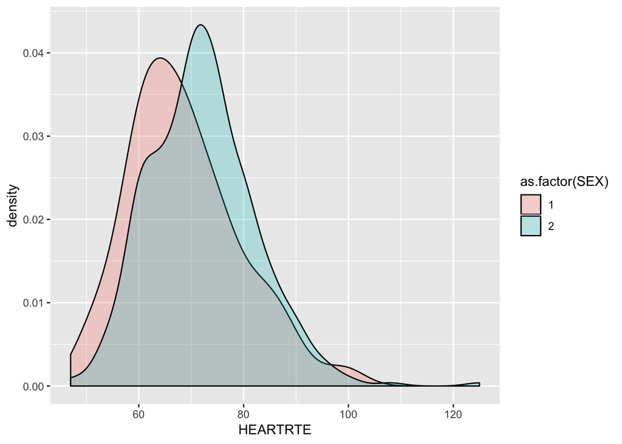

```r
# Create a subset of healthy individuals
healthy_set <- frmgham_mod %>% filter(CURSMOKE == 0, DIABP < 80, SYSBP < 120, DIABETES == 0,DEATH==0,BMI_Class=='Normal')

# Heart rate distribution in healthy people
ggplot(healthy_set, aes(x = HEARTRTE,fill = as.factor(SEX))) +
  geom_density(alpha = 0.25)
```

‘##Discussion for the last graph Looking at the healthy subset of the people For this part, we created a subset(class) using of healthy individuals from our dataset by assigning normal ranges associated with good health for the risk factors: These were no smoking, a diastolic blood pressure reading of less than 80(DIABP < 80), a systolic blood pressure reading of less than 120(SYSBP < 120), no presence of diabetes(DIABETES= 0), no death(DEATH=0), and a normal Body Mass Index(BMI_Class==’Normal’). We then used this factors to look at the heart rate for different sexes. From our assesment, after normalizing all risk factors, one sex still had a higher heart rate than the other.